# Physical Excercise Form Classification Model

Forest

August 16, 2014

## Abstract

In this R Markdown report, we examine the data collected from accelerometers on the belt, forearm, arm, and dumbell of 6 participants. Our goal is to classify whether they perform barbell lifts correctly and incorrectly in 5 different ways. We fitted a random forest model using cross-validation to control overfitting and received fairly good results.

## R Package

Here are the R packages we will need for this analysis:

```r
library(caret)
library(dplyr)
library(corrplot)
```

## Data Import and Cleaning

```r
training <- read.csv("pml-training.csv")
testing <- read.csv("pml-testing.csv")
```

There are a lot of variables and some of them have large amounts of missing values. We want to first filter out those unhelpful one and move to feature selection from there.

```r
#save classe variable
trainingClasse <- training$classe
#find all factor variables
factorCols <- sapply(training, is.factor)
#force them to numeric
toNumeric <- function(x) { as.numeric(as.character(x)) }
training <- mutate_each_q(training, funs(toNumeric), colnames(training)[factorCols])
#filter all columns with NAs
badColumns <- sapply(training, function(x){ sum(is.na(x)) > 0 })
goodTraining <- training[, !badColumns] %>% mutate(classe = trainingClasse)
#filter out index and time columns
goodTraining <- select(goodTraining, -X, -contains("time"), -num_window)
```

We will now create a training and testing set so we can estimate our out-of-sample error rate.

```r
inTrain <- createDataPartition(goodTraining$classe, p = 0.6, list = FALSE)
traindata <- goodTraining[inTrain, ]
testdata <- goodTraining[-inTrain, ]
```

## Model Tuning

We will now fit a random forest model. Because of the richness of our dataset applying cross-validation and using the whole dataset to fit the model while tuning the number of features at the same time are very time-consuming. Therefore we opt to fit the model only on a small subset with cross validation and try to come up with the optimal `mtry` parameter first. We also want to perform Principal Component Analysis on the features to narrow the feature selection pool.

```r
set.seed(1431)
#set up cross validation and only use 20% data
lgocvControl <- trainControl(method = "LGOCV", number = 10, p = 0.2)
#set up number of variables used in growing trees
rfGrid <- data.frame(mtry=1:10)
#go train
rfTune <- train(classe ~ ., traindata, preProcess = "pca", tuneGrid = rfGrid, trControl = lgocvControl)
rfTune
```

```
## Random Forest
##
## 11776 samples
##    52 predictors
##     5 classes: 'A', 'B', 'C', 'D', 'E'
##
## Pre-processing: principal component signal extraction, scaled, centered
## Resampling: Repeated Train/Test Splits Estimated (10 reps, 0.2%)
##
## Summary of sample sizes: 2356, 2356, 2356, 2356, 2356, 2356, ...
##
## Resampling results across tuning parameters:
##
##   mtry  Accuracy  Kappa  Accuracy SD  Kappa SD
##   1     0.9       0.8    0.005        0.007
##   2     0.9       0.8    0.007        0.008
##   3     0.9       0.8    0.007        0.008
##   4     0.9       0.8    0.006        0.008
##   5     0.9       0.8    0.006        0.008
##   6     0.9       0.8    0.007        0.008
##   7     0.9       0.8    0.007        0.009
##   8     0.9       0.8    0.007        0.009
##   9     0.9       0.8    0.008        0.01
##   10    0.9       0.8    0.008        0.01
##
## Accuracy was used to select the optimal model using  the largest value.
## The final value used for the model was mtry = 2.
```

## Model Final Fit

Now we can lock down the `mtry` and fit the model on the full training dataset.

```r
set.seed(12345)
cvControl <- trainControl(method = "cv")
rfFit <- train(classe ~ ., traindata, preProcess = "pca", tuneGrid = rfTune$bestTune, trControl = cvControl)
rfFit
```

```
## Random Forest
##
## 11776 samples
##    52 predictors
##     5 classes: 'A', 'B', 'C', 'D', 'E'
##
## Pre-processing: principal component signal extraction, scaled, centered
## Resampling: Cross-Validated (10 fold)
##
## Summary of sample sizes: 10598, 10599, 10600, 10599, 10598, 10599, ...
##
## Resampling results
##
##   Accuracy  Kappa  Accuracy SD  Kappa SD
##   1         1      0.005        0.006
##
## Tuning parameter 'mtry' was held constant at a value of 2
##
```

As we can see, the final model is cross-validated and received a good accuracy. We will now try the same on our testing set to see what they do.

```r
confusionMatrix(predict(rfFit, testdata), testdata$classe)
```

```
## Confusion Matrix and Statistics
##
##           Reference
## Prediction    A    B    C    D    E
##          A 2201   40    8    0    2
##          B   12 1450   35    1   10
##          C    9   25 1309   71   17
##          D    8    1   16 1211   13
##          E    2    2    0    3 1400
##
## Overall Statistics
##
##                Accuracy : 0.965
##                  95% CI : (0.961, 0.969)
##     No Information Rate : 0.284
##     P-Value [Acc > NIR] : < 2e-16
##
##                   Kappa : 0.956
##  Mcnemar's Test P-Value : 1.24e-14
##
## Statistics by Class:
##
##                      Class: A Class: B Class: C Class: D Class: E
## Sensitivity             0.986    0.955    0.957    0.942    0.971
## Specificity             0.991    0.991    0.981    0.994    0.999
## Pos Pred Value          0.978    0.962    0.915    0.970    0.995
## Neg Pred Value          0.994    0.989    0.991    0.989    0.993
## Prevalence              0.284    0.193    0.174    0.164    0.184
## Detection Rate          0.281    0.185    0.167    0.154    0.178
## Detection Prevalence    0.287    0.192    0.182    0.159    0.179
## Balanced Accuracy       0.989    0.973    0.969    0.968    0.985
```

They appear to be very good and received a similar accuracy and kappa statistics.

## Model Visulization

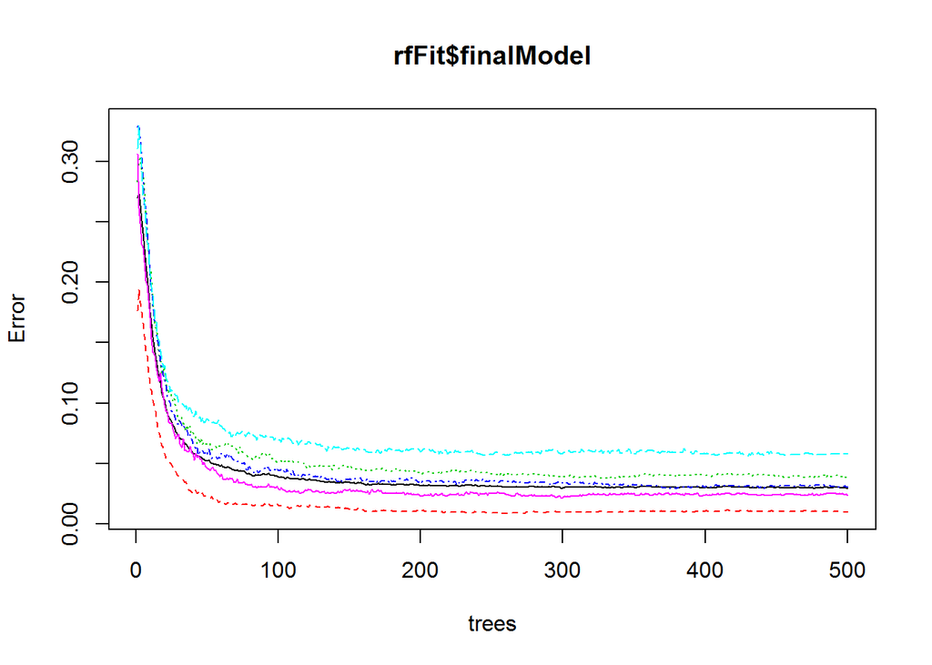

```r
plot(rfFit$finalModel)
```

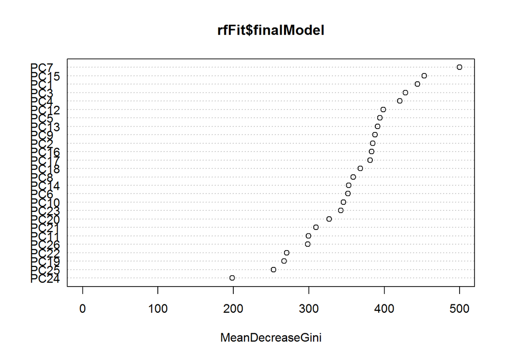

```r
varImpPlot(rfFit$finalModel)
```

## Model Output

We can now evaluate our model using final testing data

```r
pml_write_files = function(x){
  n = length(x)
  for(i in 1:n){
    filename = paste0("problem_id_",i,".txt")
    write.table(x[i],file=filename,quote=FALSE,row.names=FALSE,col.names=FALSE)
  }
}
pml_write_files(predict(rfFit, testing))
```